# Population Genetic Analysis of Mitochondrial DNA

### Diversity Statistics

We now need to generate some statistics that tell us how diverse our data are.

#### Haplotypes and Haplotype Diversity

Diversity has two components. The first is richness, or how many different types are there… in this case haplotypes. The second is evenness, or how the different types are distributed. For example an all-white school with 1 Latinx person, one African-American and 1 Asian would be less even (and thus less diverse) than your current institutions, even if the richness was the same.

If we drew two haplotypes at random from the population, haplotype diversity expresses the probability that they would be different haplotypes.

Remember that:

$$h = \frac{N}{N-1}(1 - \sum_{i=1}^n X_i)$$

Where $X_i$ is the relative haplotype frequency of each haplotype in the sample, and N is sample size.

For this we need the pegas package, and we need to write our own function, because the `hap.div()`and `nuc.div()` functions don’t stratify the data by population.

```r
# Let's create a copy of our dataset
neralb_CT_CO1_b <- neralb_CT_CO1

rownames(neralb_CT_CO1_b)<-pop

stratastat <- function(x,pop=pop,fun=nuc.div){
  #this function will calculate stats for a DNAbin object
  #(x), stratified across populations given in pop.
  # Some functions this will work with: nuc.div(),
  # theta.s(), tajima.test() from pegas, FusFs(), exptdHet() from strataG,
stats<-NULL
for(p in unique(pop)){
  stat<-fun(x[grep(p,rownames(x)),])
  stats<-c(stats,stat)
}


names(stats) <- unique(pop)
return(stats)
}

#let's try it out
hapdivs <- stratastat(neralb_CT_CO1_b,pop=pop,fun=hap.div)

hapdivs
```

```
##                       Guam_Anigua              Indonesia_Alam_Kotok
##                         1.0000000                         0.9883041
## Indonesia_Yapen-West_tip_of_Serui                Indonesia_Sangiang
##                         0.9941520                         1.0000000
##                  Malaysia_Sarawak               Philippines_Mindoro
##                         0.9458128                         1.0000000
##                 Philippines_Bohol   Papua_New_Guinea_Huon_Peninsula
##                         1.0000000                         0.9777778
##           Singapore_East_Coast_Pk              Thailand_Andaman Sea
##                         1.0000000                         1.0000000
##              Thailand_Hat_Chaweng
##                         0.9722222
```

#### Nucleotide Diversity

Remember that this is the average number of pairwise differences is between any two sequences. Recalling that:

$$\pi = \sum_{ij}x_ix_j\pi_{ij}$$
Where $x_i$ and $x_j$ are the respective frequencies of the ith and jth sequences in the sample and $\pi_{ij}$ is the number of nucleotide differences between these two sequences.

```r
nucdivs<-stratastat(neralb_CT_CO1_b,pop=pop,fun=nuc.div)
nucdivs
```

```
##                       Guam_Anigua              Indonesia_Alam_Kotok
##                       0.009118541                       0.014610996
## Indonesia_Yapen-West_tip_of_Serui                Indonesia_Sangiang
##                       0.008620843                       0.016369668
##                  Malaysia_Sarawak               Philippines_Mindoro
##                       0.007830865                       0.010371088
##                 Philippines_Bohol   Papua_New_Guinea_Huon_Peninsula
##                       0.010797227                       0.008929477
##           Singapore_East_Coast_Pk              Thailand_Andaman Sea
##                       0.014994934                       0.014947016
##              Thailand_Hat_Chaweng
##                       0.009202972
```

Here’s some optional code to convert our data to be used by the StrataG package. We can use this to double-check the calculations that were done by Pegas.

```r
neralb_g <- sequence2gtypes(neralb_CT_CO1,strata=pop)
neralb_g <- labelHaplotypes(neralb_g)
samples<- numGenotyped(neralb_g, by.strata=T)
# if strataG isn't working use this:
# samples <- neralb_g@data %>% count(stratum)

haplotypes <- numAlleles(neralb_g, by.strata=T)
```

Now let’s make a table of our various summary statistics.

```r
diversities<-cbind("# Samples" = samples$num.genotyped,
                   "# Haplotypes" = haplotypes$num.alleles,
                   "Nucleotide Diversity" = nucdivs,
                   "Haplotype Diversity" = hapdivs)

kable(diversities, digits=3)
```

[output not shown]

### F-Statistics with DNA data

Thus far we have learned about calculating $F_{ST}$ under the infinite sites model, i.e., we consider each allele or haplotype to be different from each other allele or haplotype, and always different by the same amount (whether that is one mutation or twenty mutations). We have measured genetic diversity using heterozygosity.

What if we could measure the number of differences between each allele (or haplotype)? With DNA data we can! How can we incorporate this additional information into a similar measure of subpopulation differentiation?

Using $\pi$, we can define a similar measure of population differentiation as $F_{ST}$, but this time using a measure of nucleotide diversity ($\pi$) within a population, in place of heterozygosity (H) or haplotype diversity (h).

If we define $\pi_T$ as the average nucleotide diversity in the total sampled populations, and $\pi_S$ as the average nucleotide diversity within subpopulations, then we can derive a familiar expression for an F<sub>st</sub> –like nucleotide measure of subpopulation differentiation:
$$\Phi_{ST} = \frac{\pi_T-\pi_S}{\pi_T}$$

This statistic gives us the proportion of nucleotide diversity among subpopulations, relative to the total – and their values are usually quite similar, particularly with larger sample sizes. The same things can be said for all the different ways of calculating $F_{ST}$from allelic data. Given the multitude of different descriptor variables used by different authors, and the fact that within the two classes they are trying to estimate essentially the same parameters, my convention is to refer to the allelic form of the statistic as $F_{ST}$ , and the nucleotide diversity form as $\Phi_{ST}$ , and simply mention somewhere whose formulae or program you used to calculate them.

### Pairwise Statistics on Our Data

For our purposes now, we will first be calculating **pairwise** $\Phi_{ST}$. For pairwise F-statistics, we are taking every pair of populations, and calculating $\pi_S$ and $\pi_T$ and getting $\Phi_{ST}$ for each pair. In this way, we create a distance matrix of genetic distance between each pair of populations.

The StrataG package is establishing significance of each pairwise value by randomly allocating each haplotype sequence in the pair of populations being compared into one of two bins, and measuring $\Phi_{ST}$ between them. This creates a distribution of $\Phi_{ST}$ values that would occur if there was no real structuring going on. If the true $\Phi_{ST}$ value is larger than 95% of values in this distribution, then it is deemed significantly greater than zero.

```r
pairwise_phi <- pairwiseTest(neralb_g,nrep=1000,quietly=T,model="raw")

pairwise_phi_mat <- pairwiseMatrix(pairwise_phi, stat = "PHIst")
# PhiST in lower triangle, p-value in upper triangle
kable(pairwise_phi_mat, digits=3)
```

|  | Guam_Anigua | Indonesia_Alam_Kotok | Indonesia_Sangiang | Indonesia_Yapen-West_tip_of_Serui | Malaysia_Sarawak | Papua_New_Guinea_Huon_Peninsula | Philippines_Bohol | Philippines_Mindoro | Singapore_East_Coast_Pk | Thailand_Andaman Sea | Thailand_Hat_Chaweng |
| --- | --- | --- | --- | --- | --- | --- | --- | --- | --- | --- | --- |
| Guam_Anigua | NA | 0.446 | 0.671 | 0.690 | 0.380 | 0.743 | 0.909 | 0.544 | 0.459 | 0.001 | 0.696 |
| Indonesia_Alam_Kotok | -0.017 | NA | 0.571 | 0.093 | 0.010 | 0.308 | 0.247 | 0.219 | 0.769 | 0.001 | 0.625 |
| Indonesia_Sangiang | -0.052 | -0.024 | NA | 0.122 | 0.077 | 0.475 | 0.168 | 0.209 | 0.602 | 0.001 | 0.533 |
| Indonesia_Yapen-West_tip_of_Serui | -0.063 | 0.058 | 0.055 | NA | 0.097 | 0.388 | 0.674 | 0.461 | 0.125 | 0.001 | 0.370 |
| Malaysia_Sarawak | -0.005 | 0.119 | 0.067 | 0.050 | NA | 0.517 | 0.060 | 0.047 | 0.026 | 0.001 | 0.095 |
| Papua_New_Guinea_Huon_Peninsula | -0.076 | 0.005 | -0.022 | -0.003 | -0.021 | NA | 0.546 | 0.542 | 0.487 | 0.001 | 0.555 |
| Philippines_Bohol | -0.092 | 0.032 | 0.047 | -0.022 | 0.067 | -0.019 | NA | 0.593 | 0.257 | 0.001 | 0.823 |
| Philippines_Mindoro | -0.034 | 0.037 | 0.050 | -0.011 | 0.103 | -0.025 | -0.018 | NA | 0.117 | 0.001 | 0.440 |
| Singapore_East_Coast_Pk | -0.027 | -0.068 | -0.055 | 0.060 | 0.134 | -0.001 | 0.026 | 0.049 | NA | 0.001 | 0.853 |
| Thailand_Andaman Sea | 0.803 | 0.719 | 0.669 | 0.866 | 0.891 | 0.824 | 0.846 | 0.842 | 0.699 | NA | 0.001 |
| Thailand_Hat_Chaweng | -0.064 | -0.036 | -0.027 | 0.001 | 0.076 | -0.032 | -0.045 | -0.006 | -0.057 | 0.811 | NA |

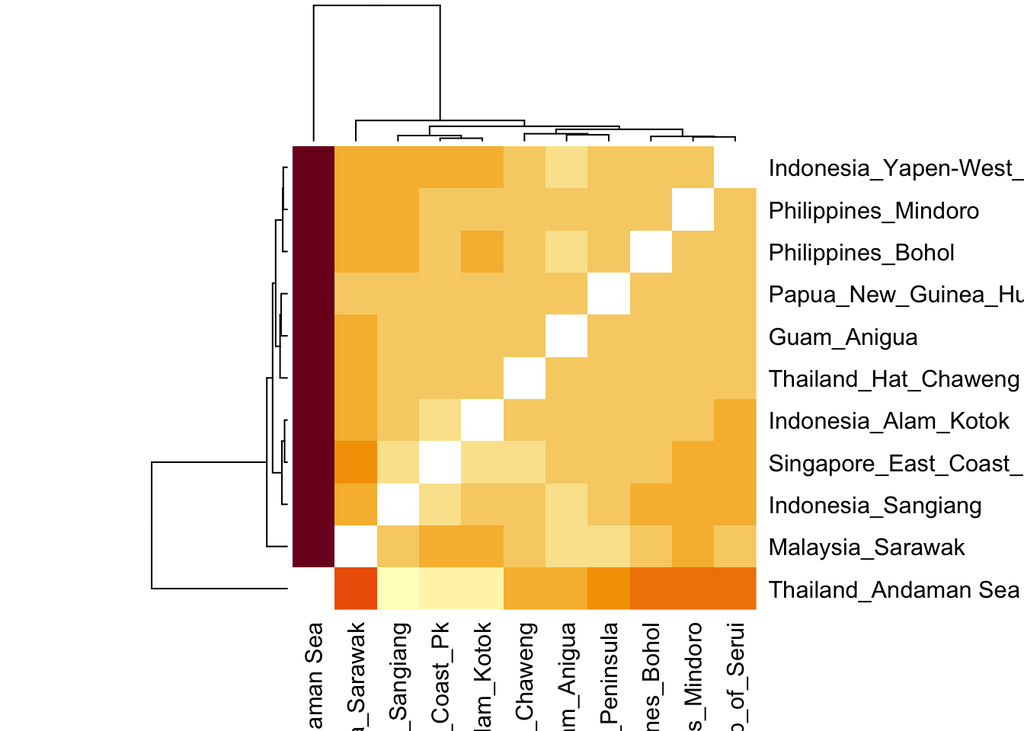

```r
phiST <- pairwise_phi_mat
phiST[upper.tri(phiST)] = t(phiST)[upper.tri(phiST)]

heatmap(phiST)
```

and we can see that $\Phi_{ST}$ values between the Andaman Sea and elsewhere are high and significant!